# Practical Machine Learning Project - WLE

vicarizmendi

6 de junio de 2016

### Introduction

This project consists in the production of a suitable classification model to find out if a Weight Lifting athlete is doing a dumbbell exercise right (class A) or wrong in 4 different ways (classes B, C, D & E).

The dataset used to train the model has been provided by:

“Velloso, E.; Bulling, A.; Gellersen, H.; Ugulino, W.; Fuks, H. Qualitative Activity Recognition of Weight Lifting Exercises. Proceedings of 4th International Conference in Cooperation with SIGCHI (Augmented Human ’13) . Stuttgart, Germany: ACM SIGCHI, 2013.”

Information about the experiment and the measures taken can be seen in:  
http://groupware.les.inf.puc-rio.br/har#weight_lifting_exercises

Read more: http://groupware.les.inf.puc-rio.br/har#ixzz4B6qSRYws

### Summary

These are the main figures of the datasets:

Training dataset: 19,622 obs x 159 predictors and the outcome

Testing dataset : 20 obs x 159 predictors, and a problem_id column, no outcome included

- 6 participants
- 5 classes of outcomes
- 4 sensors: belt, arm, forearm and dumbbell
- 13 features collected per sensor (other 25 features have been discarded)

Covariates eliminated due to different reasons:

- Features with all NAs when variable factor new_window=“yes”. As there are much more exercise observations for new_window=“no” and in the testing dataset all the observations have new_window=“no”, I have decided to simplify the modelling by eliminating from the training dataset all samples with new_window= “yes”. (25 features discarded per sensor type)
- Timestamp - Not relevant for the modelling as they are dates of the exercises, very close.
- Windows information - Not relevant for the modelling
- X - index of the samples

Using the caret package we perform the following steps:

1. Splitting the pml-train data 60/40 training/testing
2. Renaming pml-testing to be used as a final validation of the exercise and not to be confused with the testing subset created
3. Creating the preprocessing object with training data and applying it to training, testing and the validation subsets. We scale, center, eliminate zero and near zero var predictors.
4. Eliminating highly correlated features (correlation threshold 0.8), using findCorrelation() function
5. Using train() function obtain the optimized models fits, from the methods:“rpart” Trees, “qda” Quadratic Discriminant Analysis and “treebag” Bagging. We tried to do it with other methods, as “rf” Random Forest, “gbm” Boosting, “nb” Naive Bayes and “lda” Linear Discriminant Analysis. They were discarded because they were very time consuming, taking into account the tradeoff accuracy/computational time.
6. Choose the best model by predicting on the testing subset and calculating the accuracy, sensitivity and specificity.

By using the train() function from the caret package, with the default values of trControl parameter, we use as cross validation method “boot” bootstrapping , resampling 25 times the train subset with replacement.

The model with better results on the test subset for accuracy, sensitivity and specificity in all the classes A, B, C, D, and E, is “treebag” Bagging. This is the model we will use for the validation subset (pml-testing dataset).

### Loading libraries needed

Libraries: caret, rpart, ggplot2 and MASS

### Loading and cleaning data

We load the pml-training and pml-testing data sets with all fields as “character”. The data have been saved in different formats and we need to convert them to the suitable classes after loading them all.

In order to eliminate the big amount of NAs, and after realizing that there are several features with all NAs when filtering new_window=“yes”, we eliminate all rows with new_window=“yes”. There is still a big amount of observations and the pml-testing dataset has all observations with new_window=“no”.

We also eliminate x, timestamp features and window features, as they are not relevant for the problem and its outcome. The parameters needed are the measures taken from the sensors.

We eliminate the covariates with alls NAs.

The subsets resulting of this cleaning up are:

pml_training_clean, with 19216 observations and 54 features with 0 NAs

pml_testing_clean, with 20 observations and 54 features with 0 NAs

### Splitting and preprocessing training data

We are going to create from training data two subsets, training and testing, and finally we are going to use the original testing set as the final validation set.

We are going to split the original training data using 60% new training set and 40% new test set, and rename the original test set as validation set

### Cross-Validation

Approach:

1. Use the training set
2. Split it into training/test sets
3. Build a model on the training set
4. Evaluate on the test set
5. Repeat and average the estimated errors

Used for picking the type of prediction function to use.

By using the train() function from the caret package, with the default values of trControl parameter, we use as cross validation method “boot” bootstrapping , resampling 25 times the train subset with replacement.

### On the training set pick up the features

Eliminate highly correlated covariates using the findCorrelation() function from caret package,

### Training different models

#### Accuracy tradeoffs:

- Interpretability versus accuracy
- Speed versus accuracy
- Simplicity versus accuracy
- Scalability versus accuracy

In this case the interpretability has less importance than the speed, simplicity and scalability.

#### Define error rate

As this is a classification problem we choose to calculate:

- Accuracy
- Sensitivity
- Specificity
- Positive Predictive Value
- Negative Predictive Value

In order to compare models we have to get the first three figures higher.

We want to identify the cases where the quality of the exercise is bad for correcting it. The classe A is the correct one and there are 4 classes wrong. We also want to identify the error committed by the athlete during the exercise, so we want sentitivity and specificity high for all 5 classes.

The error rate will be the misclassification error.

#### On the training set pick prediction function

We train the following models:

- “rpart” tree
- “qda” Quadratic Discriminant Analysis
- “treebag” Bagging

We intend to do it as well for the following, discarding them mainly because of the high calculation time.

- “lda” Linear Discriminant Analysis
- “rf” Random forest
- “gbm” Boosting
- “nb” Naive Bayes

We predict the classes on the testing subset and calculate the confussion matrix and main statistics:

Results for “rpart”:

```
## Confusion Matrix and Statistics
##
##           Reference
## Prediction    A    B    C    D    E
##          A 1981   49  122   36    0
##          B  563  569  290   65    0
##          C  591   54  529  166    0
##          D  476  255  125  297  105
##          E  293  292  329   42  455
##
## Overall Statistics
##
##                Accuracy : 0.4986
##                  95% CI : (0.4873, 0.5098)
##     No Information Rate : 0.5081
##     P-Value [Acc > NIR] : 0.9532
##
##                   Kappa : 0.346
##  Mcnemar's Test P-Value : <2e-16
##
## Statistics by Class:
##
##                      Class: A Class: B Class: C Class: D Class: E
## Sensitivity            0.5074  0.46678  0.37921  0.49010  0.81250
## Specificity            0.9452  0.85800  0.87104  0.86423  0.86581
## Pos Pred Value         0.9054  0.38265  0.39478  0.23609  0.32247
## Neg Pred Value         0.6501  0.89511  0.86349  0.95191  0.98326
## Prevalence             0.5081  0.15864  0.18155  0.07887  0.07288
## Detection Rate         0.2578  0.07405  0.06884  0.03865  0.05921
## Detection Prevalence   0.2847  0.19352  0.17439  0.16372  0.18363
## Balanced Accuracy      0.7263  0.66239  0.62513  0.67716  0.83915
```

and the misclassification error:

```
## [1] 0.5014315
```

Results for “qda”:

```
## Confusion Matrix and Statistics
##
##           Reference
## Prediction    A    B    C    D    E
##          A 2118   36   20   10    4
##          B  139 1193  138    7   10
##          C    0   73 1250   11    6
##          D    3    7  158 1081    9
##          E    2   24   68   31 1286
##
## Overall Statistics
##
##                Accuracy : 0.9016
##                  95% CI : (0.8947, 0.9082)
##     No Information Rate : 0.2944
##     P-Value [Acc > NIR] : < 2.2e-16
##
##                   Kappa : 0.8754
##  Mcnemar's Test P-Value : < 2.2e-16
##
## Statistics by Class:
##
##                      Class: A Class: B Class: C Class: D Class: E
## Sensitivity            0.9363   0.8950   0.7650   0.9482   0.9779
## Specificity            0.9871   0.9537   0.9851   0.9730   0.9804
## Pos Pred Value         0.9680   0.8023   0.9328   0.8593   0.9114
## Neg Pred Value         0.9738   0.9774   0.9395   0.9908   0.9954
## Prevalence             0.2944   0.1735   0.2126   0.1484   0.1711
## Detection Rate         0.2756   0.1553   0.1627   0.1407   0.1674
## Detection Prevalence   0.2847   0.1935   0.1744   0.1637   0.1836
## Balanced Accuracy      0.9617   0.9243   0.8751   0.9606   0.9792
```

and the misclassification error:

```
## [1] 0.09838626
```

Results for “treebag”:

```
## Confusion Matrix and Statistics
##
##           Reference
## Prediction    A    B    C    D    E
##          A 2181    4    0    1    2
##          B   30 1443   13    0    1
##          C    1   16 1309   12    2
##          D    2    2   28 1224    2
##          E    1    0    7    1 1402
##
## Overall Statistics
##
##                Accuracy : 0.9837
##                  95% CI : (0.9806, 0.9864)
##     No Information Rate : 0.2883
##     P-Value [Acc > NIR] : < 2.2e-16
##
##                   Kappa : 0.9794
##  Mcnemar's Test P-Value : 0.0001598
##
## Statistics by Class:
##
##                      Class: A Class: B Class: C Class: D Class: E
## Sensitivity            0.9847   0.9850   0.9646   0.9887   0.9950
## Specificity            0.9987   0.9929   0.9951   0.9947   0.9986
## Pos Pred Value         0.9968   0.9704   0.9769   0.9730   0.9936
## Neg Pred Value         0.9938   0.9964   0.9924   0.9978   0.9989
## Prevalence             0.2883   0.1907   0.1766   0.1611   0.1834
## Detection Rate         0.2838   0.1878   0.1704   0.1593   0.1825
## Detection Prevalence   0.2847   0.1935   0.1744   0.1637   0.1836
## Balanced Accuracy      0.9917   0.9890   0.9799   0.9917   0.9968
```

and the misclassification error:

```
## [1] 0.01626757
```

When comparing them we see that the best of them is “treebag” bagging and the statistics are really good. In this case the expected test misclassification error is aproximately 1.6%, compared with the 9.8% in “qda” and 50% in “rpart”.

```
##                  [,1] [,2] [,3] [,4] [,5] [,6] [,7] [,8] [,9] [,10] [,11]
## Pred_Val_treebag "B"  "A"  "B"  "A"  "A"  "E"  "D"  "B"  "A"  "A"   "B"
##                  [,12] [,13] [,14] [,15] [,16] [,17] [,18] [,19] [,20]
## Pred_Val_treebag "C"   "B"   "A"   "E"   "E"   "A"   "B"   "B"   "B"
```

#### Some exploratory graphics

```
##
##              A   B   C   D   E
##   adelmo   685 442 460 302 406
##   carlitos 488 406 278 300 356
##   charles  541 432 328 366 418
##   eurico   499 373 272 340 322
##   jeremy   701 277 388 312 319
##   pedro    369 301 286 269 296
```

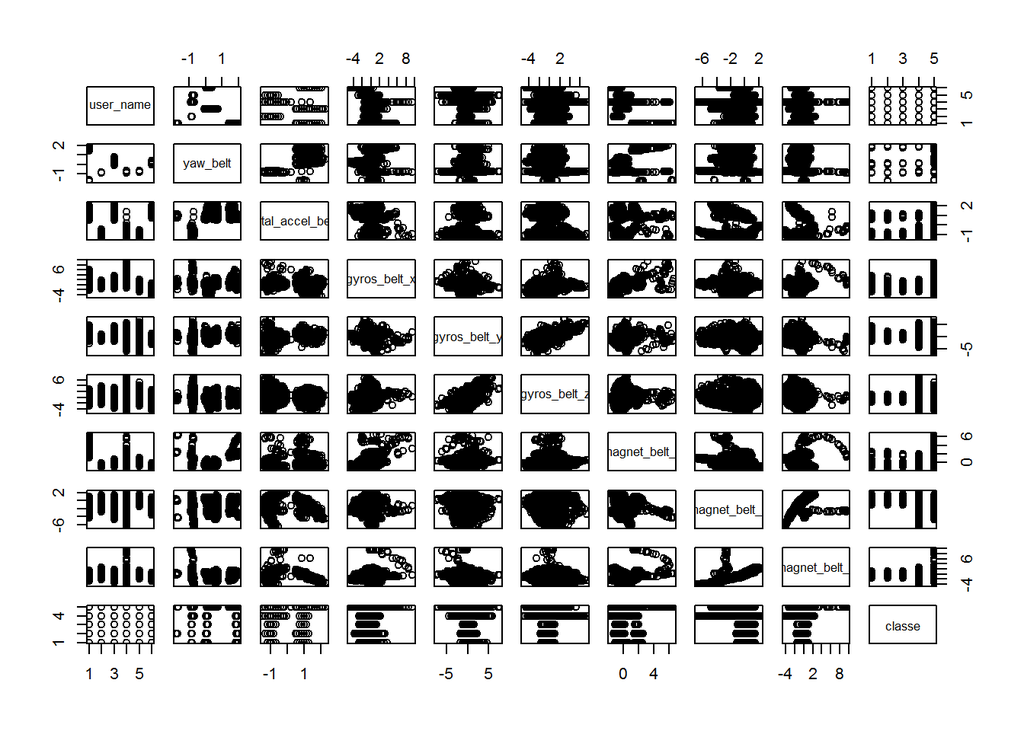

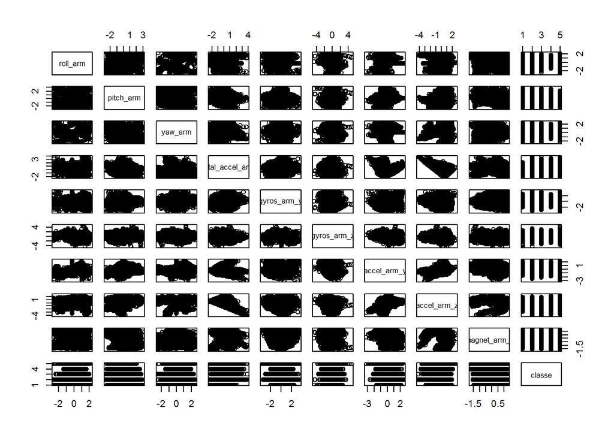

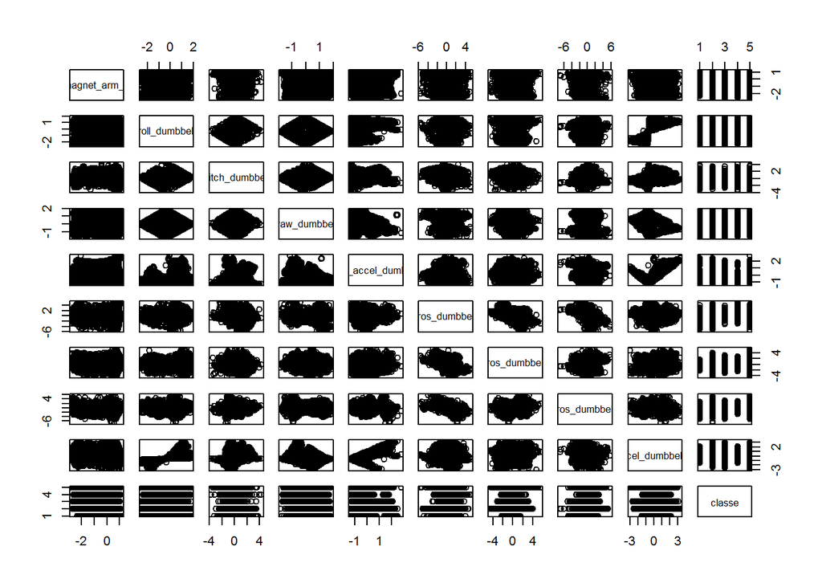

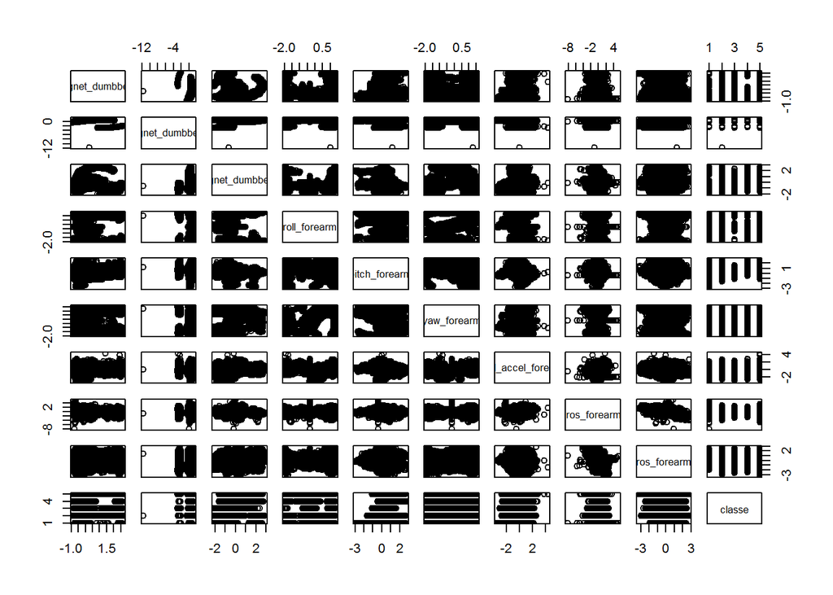

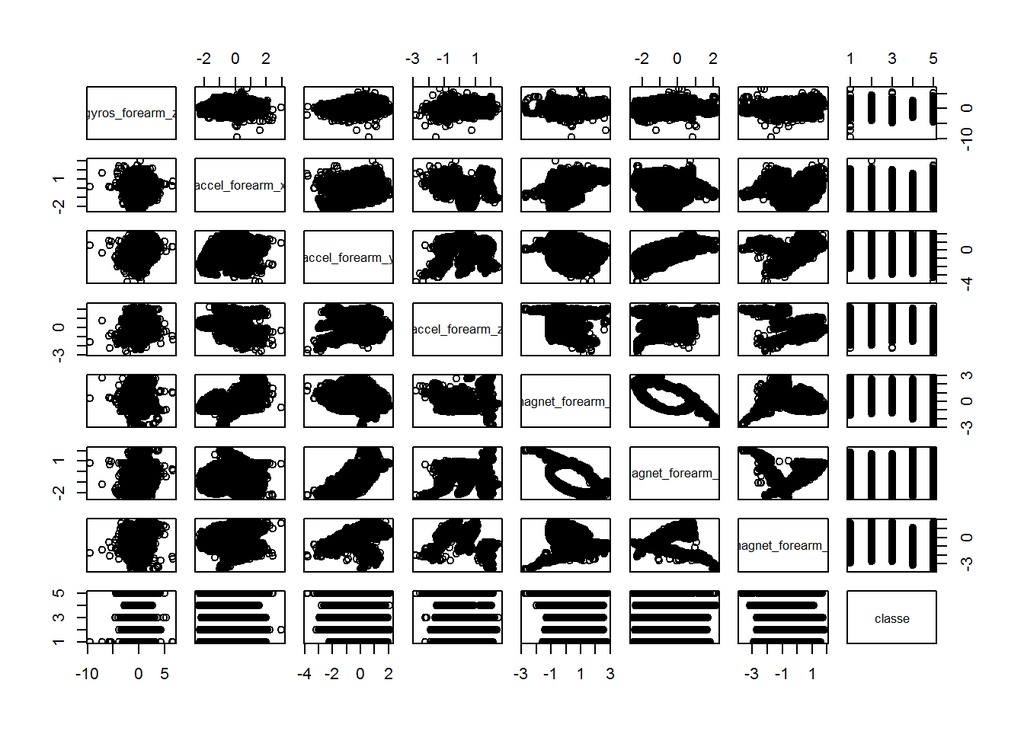